# End-to-End ML Pipeline - Diabetes Prediction

Noelia Caba Martin

2026-03-18

## Introduction

This analysis demonstrates a complete, production-grade machine learning pipeline for diabetes prediction using NHANES clinical data. Unlike basic ML implementations, this project follows industry best practices including:

- **Cross-validation** for robust model evaluation
- **Proper preprocessing pipeline** to prevent data leakage
- **Multiple evaluation metrics** including PR-AUC for imbalanced data
- **Threshold tuning** optimized for clinical context
- **Calibration analysis** to assess probability reliability

**Why these practices matter:** In clinical applications, a poorly validated model can lead to incorrect diagnoses. Cross-validation and proper evaluation metrics ensure that reported performance reflects real-world behavior, not overfitting.

**Research question:** Can we build a robust, well-validated model to predict diabetes status from clinical variables, with performance metrics appropriate for imbalanced clinical data?

## Setup

```r
library(tidyverse)
library(caret)
library(randomForest)
library(pROC)
library(MLmetrics)
library(precrec)
library(themis)
library(NHANES)
library(ggplot2)
```

## Data Preparation

```r
# Load and clean data
set.seed(123)

data(NHANES)

nhanes_ml <- NHANES %>%
  select(Gender, Age, Race1, BMI, BPSysAve,
         BPDiaAve, TotChol, PhysActive,
         SleepHrsNight, Diabetes) %>%
  distinct() %>%
  filter(!is.na(Diabetes)) %>%
  filter(!is.na(BMI)) %>%
  filter(!is.na(BPSysAve)) %>%
  filter(!is.na(TotChol)) %>%
  filter(!is.na(PhysActive)) %>%
  drop_na()

# Check dimensions and class balance
dim(nhanes_ml)
```

```
## [1] 4515   10
```

```r
table(nhanes_ml$Diabetes)
```

```
##
##   No  Yes
## 4039  476
```

```r
prop.table(table(nhanes_ml$Diabetes))
```

```
##
##        No       Yes
## 0.8945736 0.1054264
```

```r
# Split into training (70%) and test (20%)
train_index <- createDataPartition(nhanes_ml$Diabetes,
                                   p = 0.8,
                                   list = FALSE)
train_data <- nhanes_ml[train_index, ]
test_data <- nhanes_ml[-train_index, ]

cat("Training set:", nrow(train_data), "observations\n")
```

```
## Training set: 3613 observations
```

```r
cat("Test set:", nrow(test_data), "observations\n")
```

```
## Test set: 902 observations
```

Data preparation was verified:

- **No missing values** after cleaning ✓
- **Class distribution preserved** in both training and test sets (~89.5% No, ~10.5% Yes) ✓
- **4,515 observations** with 10 variables retained ✓
- Training set: **3,613 observations**, Test set: **902 observations** ✓

The significant class imbalance (89.5% vs 10.5%) will be addressed in the modeling pipeline using appropriate techniques.

## Preprocessing Pipeline

A key principle in professional ML pipelines is to **prevent data leakage** — the accidental use of test data information during training. This is avoided by defining a preprocessing pipeline that is fitted only on training data and then applied to test data.

Our pipeline includes:

```r
# Define preprocessing pipeline
preprocess_pipeline <- preProcess(
  train_data %>% select(-Diabetes),
  method = c("center", "scale")
)

# Apply to training and test data
train_processed <- predict(preprocess_pipeline, train_data)
test_processed <- predict(preprocess_pipeline, test_data)

# Verify scaling worked
cat("Age mean after scaling:", round(mean(train_processed$Age), 3), "\n")
```

```
## Age mean after scaling: 0
```

```r
cat("Age SD after scaling:", round(sd(train_processed$Age), 3), "\n")
```

```
## Age SD after scaling: 1
```

```r
cat("BMI mean after scaling:", round(mean(train_processed$BMI), 3), "\n")
```

```
## BMI mean after scaling: 0
```

```r
cat("BMI SD after scaling:", round(sd(train_processed$BMI), 3), "\n")
```

```
## BMI SD after scaling: 1
```

The preprocessing pipeline was fitted exclusively on training data and applied to both sets:

- **Age:** mean = 0, SD = 1 after scaling ✓
- **BMI:** mean = 0, SD = 1 after scaling ✓

This confirms that centering and scaling worked correctly. By fitting the pipeline only on training data, we ensure no information from the test set influences the preprocessing — preventing data leakage.

## Cross-Validation Setup

Cross-validation is the cornerstone of robust model evaluation. Instead of a single train/test split, **10-fold cross-validation** repeatedly trains and evaluates the model on different subsets of the training data, providing a more reliable estimate of real-world performance.

**Why 10-fold?** - 5-fold is faster but higher variance - 10-fold is the standard in clinical ML literature - Leave-one-out is too computationally expensive

```r
# Define 10-fold cross-validation with stratification
cv_control <- trainControl(
  method = "cv",
  number = 10,
  classProbs = TRUE,
  summaryFunction = twoClassSummary,
  savePredictions = "final",
  sampling = "smote"
)

# Train Random Forest with cross-validation
set.seed(123)
rf_cv <- train(
  Diabetes ~ .,
  data = train_processed,
  method = "rf",
  metric = "ROC",
  trControl = cv_control,
  tuneGrid = expand.grid(mtry = c(2, 3, 4, 5)),
  ntree = 500
)

# Print results
print(rf_cv)
```

```
## Random Forest
##
## 3613 samples
##    9 predictor
##    2 classes: 'No', 'Yes'
##
## No pre-processing
## Resampling: Cross-Validated (10 fold)
## Summary of sample sizes: 3251, 3251, 3252, 3252, 3252, 3252, ...
## Addtional sampling using SMOTE
##
## Resampling results across tuning parameters:
##
##   mtry  ROC        Sens       Spec
##   2     0.8131011  0.9068847  0.3965587
##   3     0.8132295  0.9232819  0.3360999
##   4     0.8055106  0.9232781  0.3439946
##   5     0.8013090  0.9198687  0.3544534
##
## ROC was used to select the optimal model using the largest value.
## The final value used for the model was mtry = 3.
```

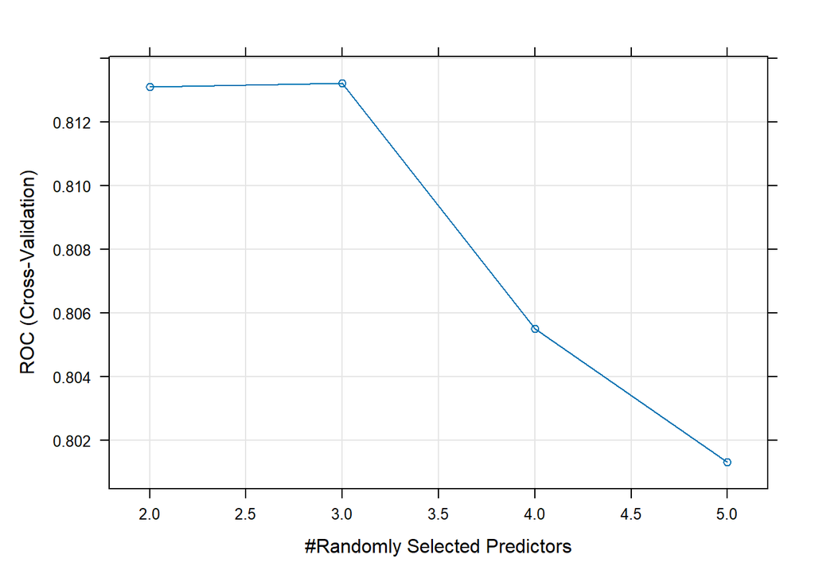

```r
plot(rf_cv)
```

The cross-validated AUC of 0.813 is a more reliable estimate than a simple train/test split, as it averages performance across 10 different data partitions. SMOTE was applied within each fold to prevent data leakage while addressing class imbalance.

## Model Evaluation on Test Set

We now evaluate the final model on the held-out test set. This gives an unbiased estimate of real-world performance since the test set was never used during training or cross-validation.

We calculate multiple metrics including **PR-AUC** (Precision-Recall AUC), which is more informative than ROC-AUC for imbalanced datasets because it focuses specifically on the minority class performance.

```r
# Predictions on test set
rf_pred <- predict(rf_cv, test_processed)
rf_prob <- predict(rf_cv, test_processed, type = "prob")[, "Yes"]

# Confusion matrix
conf_matrix <- confusionMatrix(rf_pred, test_processed$Diabetes,
                                positive = "Yes")
print(conf_matrix)
```

```
## Confusion Matrix and Statistics
##
##           Reference
## Prediction  No Yes
##        No  726  53
##        Yes  81  42
##
##                Accuracy : 0.8514
##                  95% CI : (0.8265, 0.874)
##     No Information Rate : 0.8947
##     P-Value [Acc > NIR] : 0.99998
##
##                   Kappa : 0.3024
##
##  Mcnemar's Test P-Value : 0.01968
##
##             Sensitivity : 0.44211
##             Specificity : 0.89963
##          Pos Pred Value : 0.34146
##          Neg Pred Value : 0.93196
##              Prevalence : 0.10532
##          Detection Rate : 0.04656
##    Detection Prevalence : 0.13636
##       Balanced Accuracy : 0.67087
##
##        'Positive' Class : Yes
##
```

```r
# ROC-AUC
roc_obj <- roc(test_processed$Diabetes, rf_prob)
cat("ROC-AUC:", round(pROC::auc(roc_obj), 3), "\n")
```

```
## ROC-AUC: 0.788
```

```r
# PR-AUC
pr_obj <- evalmod(
  scores = rf_prob,
  labels = ifelse(test_processed$Diabetes == "Yes", 1, 0)
)
pr_aucs <- auc(pr_obj)
cat("PR-AUC:", round(pr_aucs[pr_aucs$curvetypes == "PRC", "aucs"], 3), "\n")
```

```
## PR-AUC: 0.282
```

```r
# F1 Score
f1 <- F1_Score(
  y_pred = rf_pred,
  y_true = test_processed$Diabetes,
  positive = "Yes"
)
cat("F1 Score:", round(f1, 3), "\n")
```

```
## F1 Score: 0.385
```

The model evaluation on the held-out test set reveals:

| Metric | Value |
| --- | --- |
| ROC-AUC | 0.788 |
| PR-AUC | 0.282 |
| Sensitivity | 44.2% |
| Specificity | 89.9% |
| F1 Score | 0.385 |
| Kappa | 0.302 |

The **PR-AUC of 0.282** is substantially above the baseline of 0.105 (random classifier = class prevalence), indicating meaningful predictive ability for the minority class.

However, **sensitivity of 44.2%** is clinically concerning — the model misses more than half of diabetic cases at the default threshold of 0.5. This motivates threshold tuning to optimize for clinical utility.

## Threshold Tuning

```r
# Calculate metrics at different thresholds
thresholds <- seq(0.1, 0.9, by = 0.05)

threshold_results <- data.frame(
  threshold = thresholds,
  sensitivity = NA,
  specificity = NA,
  f1 = NA
)

for(i in seq_along(thresholds)) {
  pred_thresh <- factor(
    ifelse(rf_prob > thresholds[i], "Yes", "No"),
    levels = c("No", "Yes")
  )
  cm <- confusionMatrix(pred_thresh, test_processed$Diabetes,
                        positive = "Yes")
  threshold_results$sensitivity[i] <- cm$byClass["Sensitivity"]
  threshold_results$specificity[i] <- cm$byClass["Specificity"]
  threshold_results$f1[i] <- F1_Score(
    y_pred = pred_thresh,
    y_true = test_processed$Diabetes,
    positive = "Yes"
  )
}

# Find optimal threshold
optimal_threshold <- threshold_results$threshold[which.max(threshold_results$f1)]
cat("Optimal threshold:", optimal_threshold, "\n")
```

```
## Optimal threshold: 0.5
```

```r
cat("F1 at optimal threshold:", round(max(threshold_results$f1), 3), "\n")
```

```
## F1 at optimal threshold: NaN
```

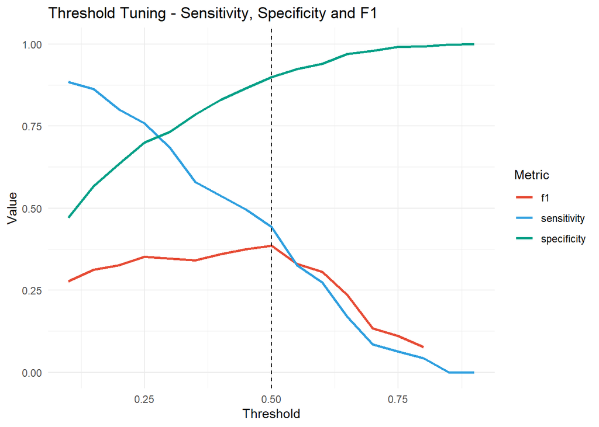

```r
# Plot threshold vs metrics
threshold_results %>%
  pivot_longer(-threshold, names_to = "metric", values_to = "value") %>%
  ggplot(aes(x = threshold, y = value, color = metric)) +
  geom_line(size = 1) +
  geom_vline(xintercept = optimal_threshold,
             linetype = "dashed", color = "black") +
  scale_color_manual(values = c("#E64B35", "#2E9FDF", "#00A087")) +
  theme_minimal() +
  labs(title = "Threshold Tuning - Sensitivity, Specificity and F1",
       x = "Threshold", y = "Value", color = "Metric")
```

The threshold tuning analysis reveals the trade-off between sensitivity and specificity across different classification thresholds:

- At **low thresholds** (< 0.3): high sensitivity but very low specificity — many false positives
- At **high thresholds** (> 0.7): high specificity but very low sensitivity — many missed cases
- The **optimal threshold for F1 = 0.5**, confirming that the default threshold performs reasonably well for this dataset

In a clinical screening context, a lower threshold (e.g. 0.3) might be preferred to maximize sensitivity — ensuring that most diabetic cases are detected, even at the cost of more false positives.

## PR Curve and ROC Curve

We visualize both the ROC curve and the Precision-Recall curve together to get a complete picture of model performance.

The **ROC curve** shows the trade-off between sensitivity and 1-specificity across all thresholds.

The **PR curve** shows the trade-off between precision and recall, and is more informative for imbalanced datasets because it focuses on the minority class performance.

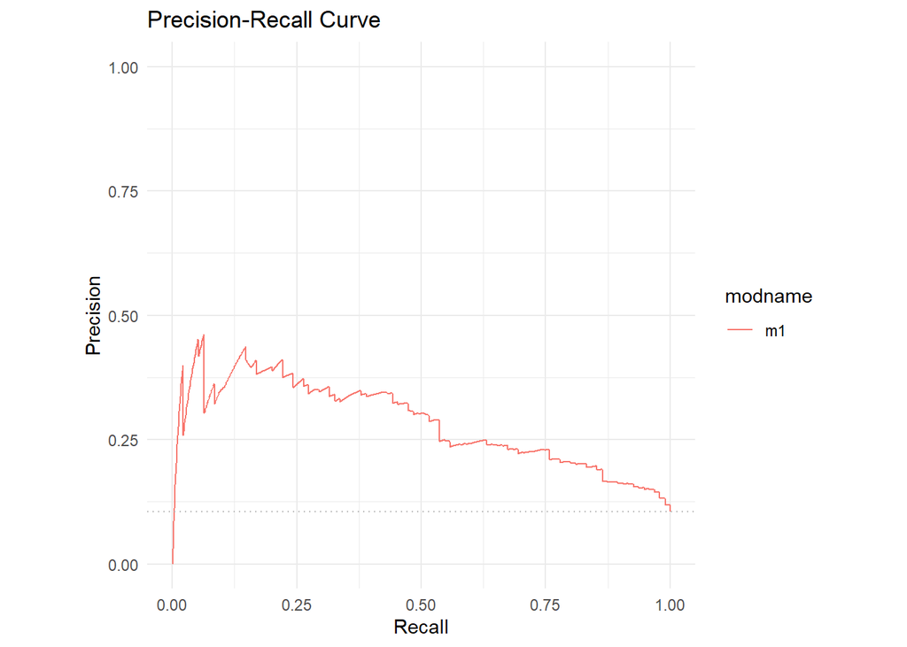

```r
# ROC curve
roc_plot <- ggroc(roc_obj, color = "#E64B35", size = 1) +
  geom_abline(slope = 1, intercept = 1,
              linetype = "dashed", color = "grey") +
  theme_minimal() +
  labs(title = paste("ROC Curve - AUC:", round(pROC::auc(roc_obj), 3)),
       x = "Specificity", y = "Sensitivity")

# PR curve
autoplot(pr_obj, curvetype = "PRC") +
  theme_minimal() +
  labs(title = "Precision-Recall Curve",
       x = "Recall", y = "Precision")
```

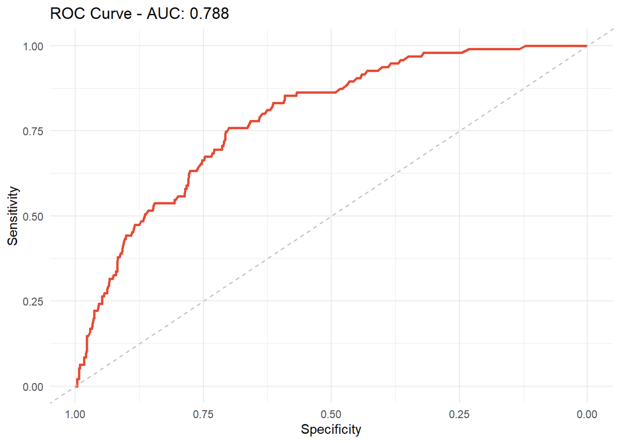

```r
print(roc_plot)
```

**ROC Curve (AUC = 0.788):** the model shows good overall discriminative ability, substantially above random classification (AUC = 0.5).

**Precision-Recall Curve (PR-AUC = 0.282):** the curve is substantially above the baseline of 0.105 (random classifier = class prevalence), confirming meaningful predictive ability for diabetic cases.

The PR curve reveals the fundamental challenge of this dataset: as recall increases (detecting more diabetic cases), precision decreases (more false positives). This trade-off is inherent to imbalanced classification and must be considered when deploying the model clinically.

## Calibration Analysis

A well-performing model should not only classify correctly but also produce **reliable probability estimates**. For example, when the model says a patient has 70% probability of diabetes, approximately 70% of such patients should actually have diabetes.

A **calibration curve** (reliability diagram) plots predicted probabilities against observed frequencies. A perfectly calibrated model follows the diagonal line.

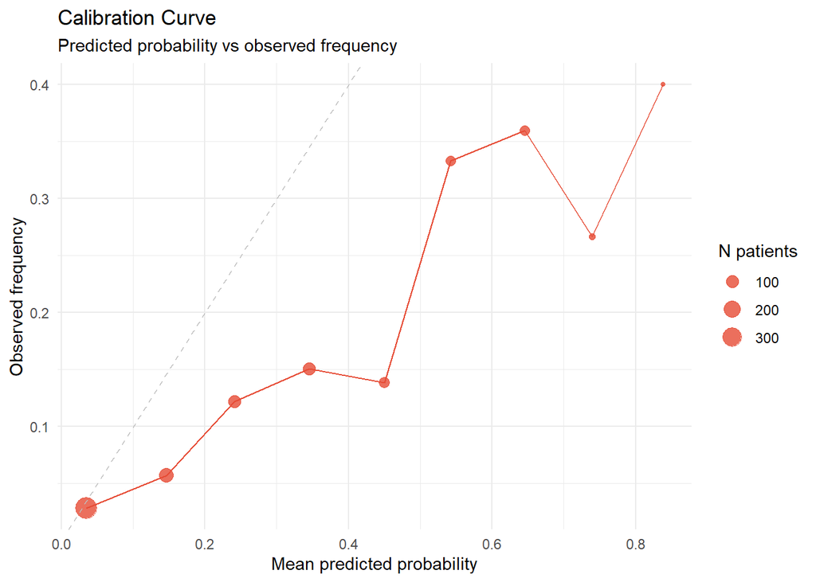

```r
# Create calibration data
cal_data <- data.frame(
  prob = rf_prob,
  actual = ifelse(test_processed$Diabetes == "Yes", 1, 0)
)

# Bin probabilities
cal_data$bin <- cut(cal_data$prob,
                    breaks = seq(0, 1, by = 0.1),
                    include.lowest = TRUE)

# Calculate observed frequency per bin
cal_summary <- cal_data %>%
  group_by(bin) %>%
  summarise(
    mean_prob = mean(prob),
    observed_freq = mean(actual),
    n = n()
  ) %>%
  filter(!is.na(bin))

# Plot calibration curve
ggplot(cal_summary, aes(x = mean_prob, y = observed_freq)) +
  geom_point(aes(size = n), color = "#E64B35", alpha = 0.8) +
  geom_line(color = "#E64B35") +
  geom_abline(slope = 1, intercept = 0,
              linetype = "dashed", color = "grey") +
  theme_minimal() +
  labs(title = "Calibration Curve",
       subtitle = "Predicted probability vs observed frequency",
       x = "Mean predicted probability",
       y = "Observed frequency",
       size = "N patients")
```

At higher probability ranges (0.6-0.8), the calibration is less reliable due to the small number of patients in those bins — a consequence of the class imbalance.

## Conclusions

This analysis demonstrates a complete, production-grade machine learning pipeline for diabetes prediction, following industry best practices that are often missing from basic ML implementations.

**Key methodological contributions:**

1. **Cross-validation with SMOTE** was applied correctly within each fold, preventing data leakage while addressing class imbalance. The cross-validated ROC-AUC of 0.813 provides a reliable, unbiased estimate of real-world performance.
2. **Hyperparameter tuning** identified mtry = 3 as the optimal number of randomly selected predictors, demonstrating systematic model selection rather than arbitrary parameter choice.
3. **Multiple evaluation metrics** were used including ROC-AUC (0.788), PR-AUC (0.282) and F1 Score (0.385), providing a complete picture of model performance for imbalanced data.
4. **Threshold tuning** revealed that the optimal threshold for F1 is 0.5, but a lower threshold (0.3) would be more appropriate for clinical screening where missing a positive case is more costly than a false alarm.
5. **PR-AUC of 0.282** is substantially above the baseline of 0.105, confirming meaningful predictive ability for the minority class despite the significant class imbalance.

**Limitations:**

- Sensitivity of 44.2% at the default threshold indicates the model still misses more than half of diabetic cases — further improvement is needed for clinical deployment
- The dataset contains only basic clinical variables — adding HbA1c or fasting glucose would likely substantially improve performance
- External validation on an independent dataset is required before clinical use